# R exercise 6: Paritioning and Hierarchal Clustering

Kelsey Gonzalez and Laura Werthmann

Due Nov 27, 2019

Load packages

```r
library(tidyverse) # for data cleaning and visualization
library(ISLR) # for college dataset
library(cluster) # for gower similarity, pam, and diana (a divisive hierarchical method). clara() is also included, which is basically pam by sampling
library(Rtsne) # for t-SNE plot
library(ggdendro)
library(factoextra) #for hopkins statistic
library(clustertend) #for hopkins statistic
```

Clustering requires 1. Calculating distance among the observations 2. Choosing a clustering algorithm 3. Selecting the number of clusters

load data

```r
rm(list=ls())
load("LifeExpectancyData_3.Rdata")
data$Status = as.factor(data$Status)
data$Year = as.factor(data$Year)
data$Country = as.factor(data$Country)

data <- data %>% filter(Year=="2013") %>% select(-c(Year, Polio, "percentage expenditure", Measles, `HIV/AIDS`)) %>% drop_na()

#create a quick df with only numberical variables
data_no_cat <- data %>% select(-Status, -region, -Country)
data_no_cat <- as.data.frame(data_no_cat)
rownames(data_no_cat) <- data$Country
```

First things first, do our data even have a natural clustering tendency? the smaller the result, the higher clustering tendency

```r
#Hopkins, for numerical data only
# Compute Hopkins statistic for iris dataset:n must be no larger than num of samples
# seed set internally in the function, always give the same result.
res <- get_clust_tendency(data_no_cat, n=138, graph = TRUE)
res$hopkins_stat
```

```
## [1] 0.1162774
```

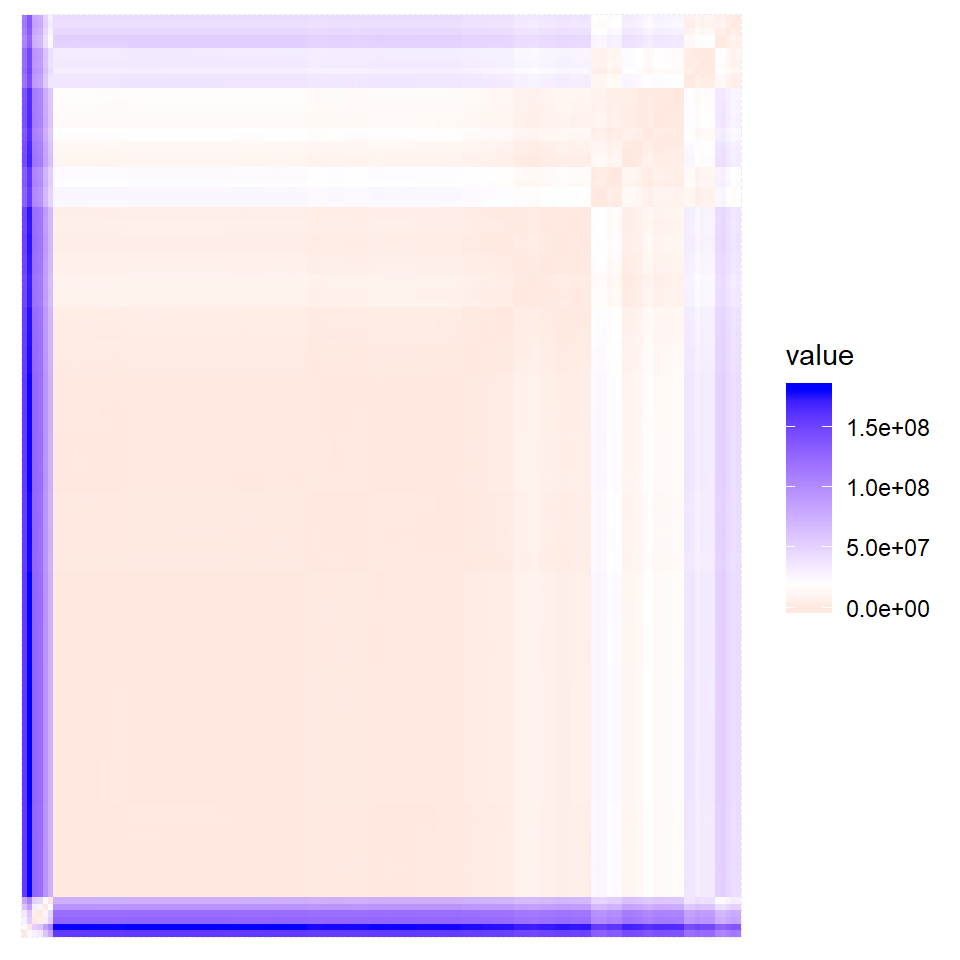

```r
res$plot
```

```r
set.seed(1)
res <- hopkins(data_no_cat, n = 138)
res$H #very small, < 0.5, good clustering tendency
```

```
## [1] 0.1685528
```

calculating distance the Gower distance for mixed variable types in package cluster

*Gower distance*: For each variable type, a particular distance metric that works well for that type is used and scaled to fall between 0 and 1. Then, a linear combination using user-specified weights (most simply an average) is calculated to create the final distance matrix.

The metrics used for each data type are described below:

*quantitative (interval)*: range-normalized Manhattan distance  
*ordinal*: variable is first ranked, then Manhattan distance is used with a special adjustment for ties  
*nominal*: variables of k categories are first converted into k binary columns and then the Dice coefficient is used

*pros*: Intuitive to understand and straightforward to calculate

```r
gower_dist <- daisy(data[, -1],
                    metric = "gower",
                    type = list(logratio = "GDP",
                                logratio = "Population"))

# Check attributes to ensure the correct methods are being used (I = interval, N = nominal)
# Note that despite logratio being called, the type remains coded as "I"
summary(gower_dist)
```

```
## 9591 dissimilarities, summarized :
##    Min. 1st Qu.  Median    Mean 3rd Qu.    Max.
## 0.02333 0.17078 0.23395 0.24421 0.30734 0.65386
## Metric :  mixed ;  Types = N, I, I, I, I, I, I, I, I, I, I, I, I, I, I, N
## Number of objects : 139
```

```r
# cleaning it up
gower_mat <- as.matrix(gower_dist)
rownames(gower_mat) <- colnames(gower_mat) <- data$Country
```

Output most similar pair, excluding dissimilar scores of 0 (one compared to itself)

```r
data[
  which(gower_mat == min(gower_mat[gower_mat != min(gower_mat)]),
        arr.ind = TRUE)[1, ], ]
```

```
## # A tibble: 2 x 17
##   Country Status `Life expectanc~ `Adult Mortalit~ `infant deaths` Alcohol
##   <fct>   <fct>             <dbl>            <dbl>           <dbl>   <dbl>
## 1 Nether~ Devel~             81.4                6               1    8.68
## 2 Denmark Devel~             81                 75               0    9.5
## # ... with 11 more variables: BMI <dbl>, `under-five deaths` <dbl>, `Total
## #   expenditure` <dbl>, Diphtheria <dbl>, GDP <dbl>, Population <dbl>,
## #   `thinness 1-19 years` <dbl>, `thinness 5-9 years` <dbl>, `Income
## #   composition of resources` <dbl>, Schooling <dbl>, region <fct>
```

```r
data[which(gower_mat==max(gower_mat), arr.ind = TRUE)[1, ], ]
```

```
## # A tibble: 2 x 17
##   Country Status `Life expectanc~ `Adult Mortalit~ `infant deaths` Alcohol
##   <fct>   <fct>             <dbl>            <dbl>           <dbl>   <dbl>
## 1 Nether~ Devel~             81.4                6               1    8.68
## 2 India   Devel~             67.6              187            1000    3.11
## # ... with 11 more variables: BMI <dbl>, `under-five deaths` <dbl>, `Total
## #   expenditure` <dbl>, Diphtheria <dbl>, GDP <dbl>, Population <dbl>,
## #   `thinness 1-19 years` <dbl>, `thinness 5-9 years` <dbl>, `Income
## #   composition of resources` <dbl>, Schooling <dbl>, region <fct>
```

### Use PAM (partitioning around medoids) to perform the clustering

Calculate Silhouette width for 2 to 10 clusters using PAM

```r
sil <- c(NA)
for(i in 2:10){
  pam_fit <- pam(gower_mat, diss=TRUE, k=i)
  sil[i] <-pam_fit$silinfo$avg.width
}
```

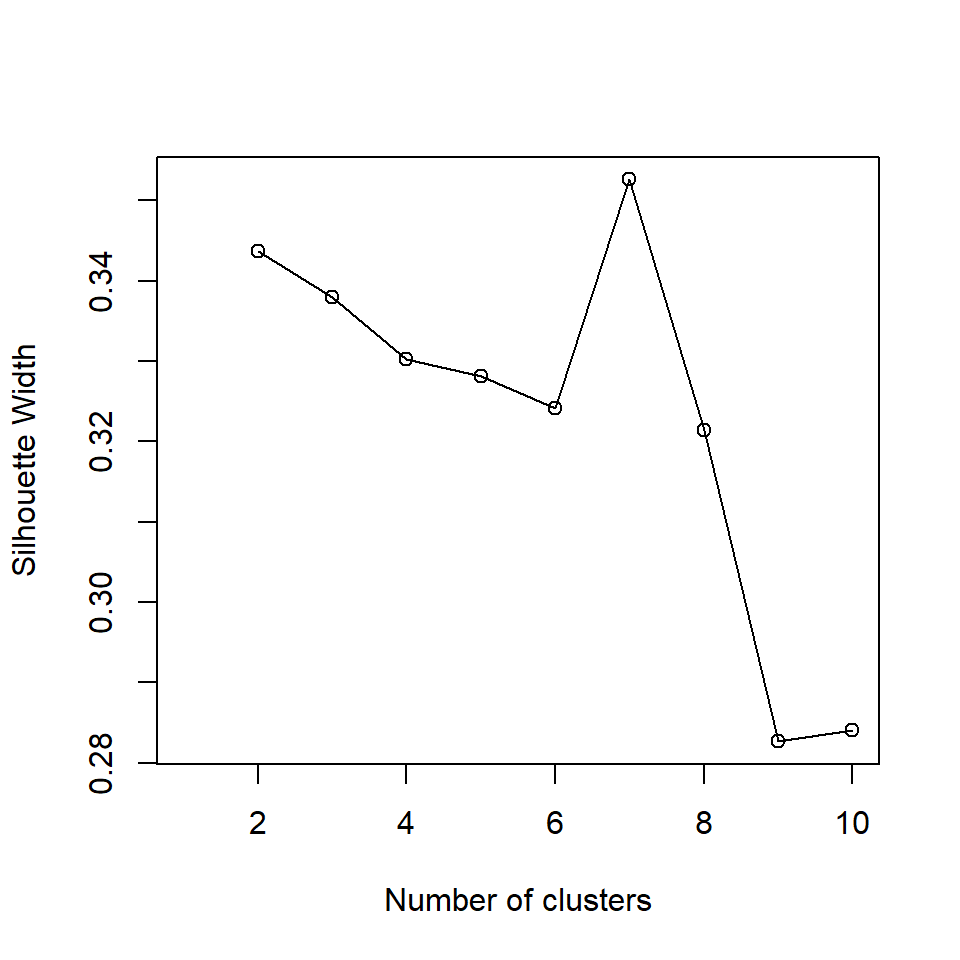

```r
plot(1:10, sil,
xlab = "Number of clusters",
ylab = "Silhouette Width",
lines(1:10, sil))
```

Cluster Interpretation: via Descriptive Statistics

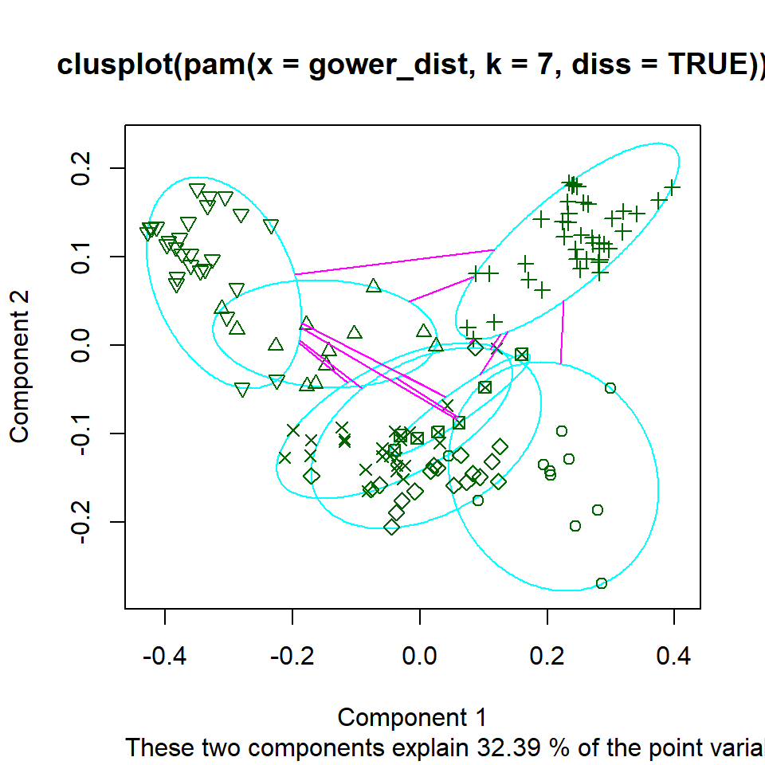

```r
pam_fit <- pam(gower_dist, diss = TRUE, k = 7)
# add cluster labels to the data. We will use result1 later
data_clean <- data.frame(data, pam_fit$cluster)
# show clustering results by country
result1 <- data_clean %>% select(Country,pam_fit.cluster)
View(result1)
clusplot(pam_fit)
```

## 1.run Kmean or PAM on your dataset (run it multiple times without setting set.seed()). Report differences in performance between runs (Silhouette width or overlaps of observations in different clustering). Can you make sense of the clusters produced?

Our data shows a lot of overlapping variables within the 3 clusters. As we increase the distance, the point variability lowers and spreads the data out more, providing more sparse data making it harder to view “clear” clusters.

the 91.31% of point vairability showing the information of the 3 clusters on a 2d scale.

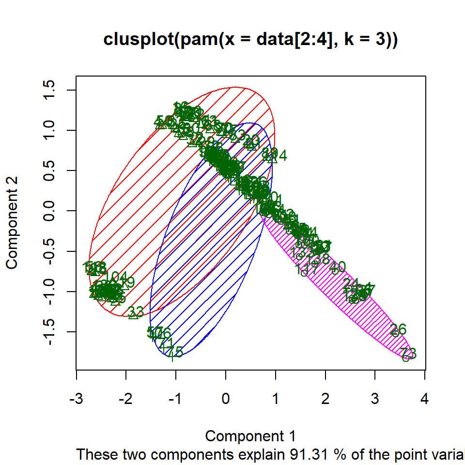

```r
PAM3 <- pam(data[2:4],3)
clusplot(PAM3, color=TRUE, shade=T, labels =3, lines=0)
```

Another run of the data with differnt distance measures shows a lower point variability at 63.68%

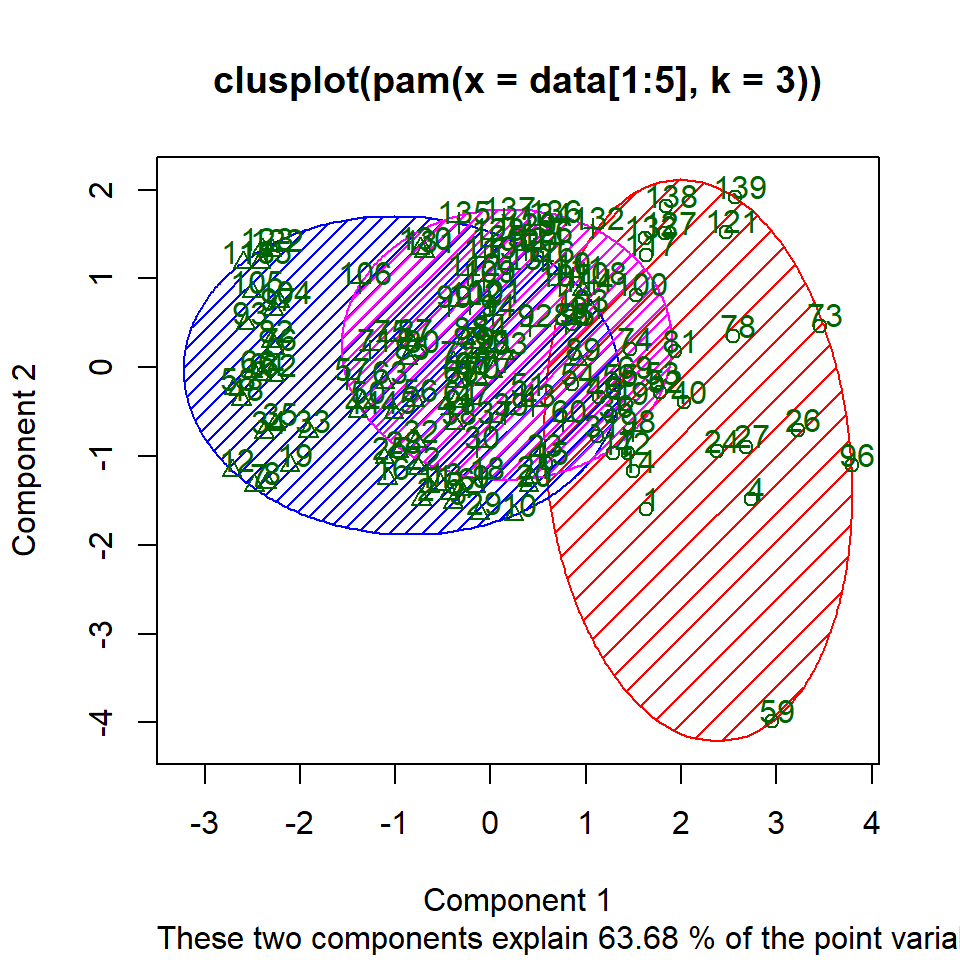

```r
PAM3 <- pam(data[1:5],3)
clusplot(PAM3, color=TRUE, shade=T, labels =3, lines=0)
```

Two clusters doesn’t change much, just in that now there are two clusters.

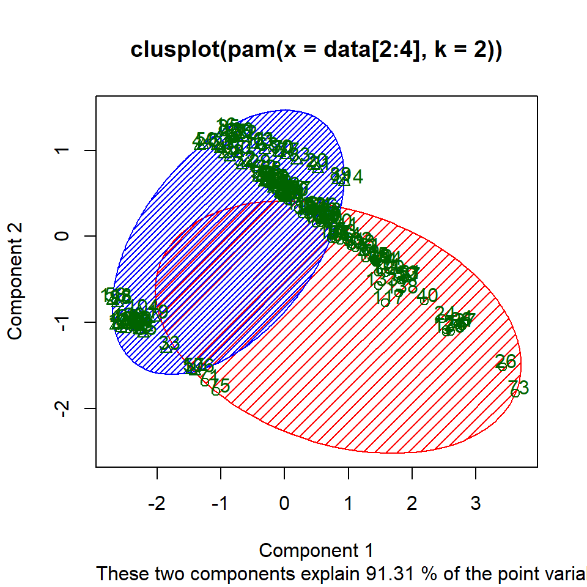

```r
PAM3 <- pam(data[2:4],2)
clusplot(PAM3, color=TRUE, shade=T, labels =3, lines=0)
```

A slightly smaller distance interval [2:5] shows a higher point variability than before, but lower than the first instance of [2:4]

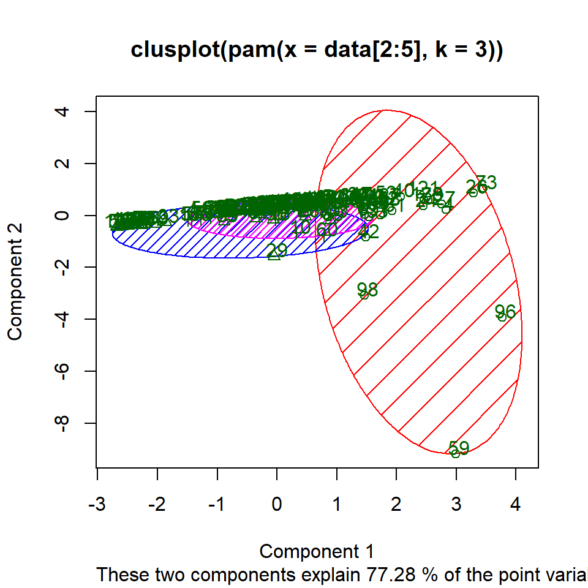

```r
PAM3 <- pam(data[2:5],3)
clusplot(PAM3, color=TRUE, shade=T, labels =3, lines=0)
```

A plot with all numeric columns

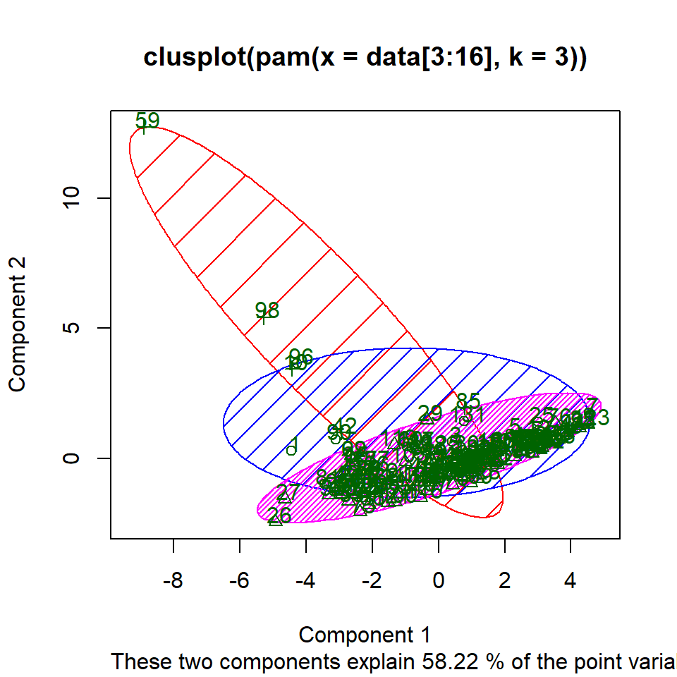

```r
PAM3 <- pam(data[3:16],3)
clusplot(PAM3, color=TRUE, shade=T, labels =3, lines=0)
```

group_by cluster and then compute the summary data (means, median, etc) for each cluster

```r
data_results <- data_clean %>%
  mutate(cluster = pam_fit.cluster) %>% #add the cluster column
  select(-pam_fit.cluster) %>%
  group_by(cluster) %>% #group countries by its cluster
  do(the_summary = summary(.)) #do: summarize by group/cluster,add the_summary column

data_results$the_summary
```

```
## [[1]]
##         Country         Status   Life.expectancy Adult.Mortality
##  Afghanistan:1   Developed : 0   Min.   :59.90   Min.   : 22.0
##  Bangladesh :1   Developing:11   1st Qu.:66.90   1st Qu.:138.5
##  Bhutan     :1                   Median :67.80   Median :162.0
##  Cambodia   :1                   Mean   :68.83   Mean   :154.8
##  India      :1                   3rd Qu.:70.15   3rd Qu.:185.0
##  Maldives   :1                   Max.   :77.90   Max.   :268.0
##  (Other)    :5
##  infant.deaths       Alcohol            BMI        under.five.deaths
##  Min.   :   0.0   Min.   :0.0100   Min.   :16.60   Min.   :   0.0
##  1st Qu.:   2.5   1st Qu.:0.0100   1st Qu.:17.75   1st Qu.:   2.5
##  Median :  19.0   Median :0.0100   Median :18.20   Median :  24.0
##  Mean   : 146.5   Mean   :0.6127   Mean   :20.10   Mean   : 187.9
##  3rd Qu.:  85.0   3rd Qu.:0.4850   3rd Qu.:22.40   3rd Qu.: 109.5
##  Max.   :1000.0   Max.   :3.1100   Max.   :25.10   Max.   :1300.0
##
##  Total.expenditure   Diphtheria         GDP           Population
##  Min.   : 1.290    Min.   :64.00   Min.   : 117.8   Min.   :      393
##  1st Qu.: 2.790    1st Qu.:78.50   1st Qu.: 298.6   1st Qu.:   974664
##  Median : 3.830    Median :83.00   Median : 688.6   Median :  2798531
##  Mean   : 4.725    Mean   :85.64   Mean   :1283.8   Mean   : 50599411
##  3rd Qu.: 5.810    3rd Qu.:96.50   3rd Qu.:1220.6   3rd Qu.: 89652212
##  Max.   :11.160    Max.   :99.00   Max.   :7112.3   Max.   :181712595
##
##  thinness..1.19.years thinness.5.9.years Income.composition.of.resources
##  Min.   :11.00        Min.   : 2.00      Min.   :0.4700
##  1st Qu.:13.30        1st Qu.:12.20      1st Qu.:0.5425
##  Median :15.90        Median :15.10      Median :0.5650
##  Mean   :16.21        Mean   :14.85      Mean   :0.5865
##  3rd Qu.:18.00        3rd Qu.:17.10      3rd Qu.:0.6095
##  Max.   :26.80        Max.   :27.50      Max.   :0.7570
##
##    Schooling          region      cluster
##  Min.   : 7.70           : 0   Min.   :1
##  1st Qu.: 9.95   Africa  : 0   1st Qu.:1
##  Median :11.50   Americas: 0   Median :1
##  Mean   :11.15   Asia    :11   Mean   :1
##  3rd Qu.:12.45   Europe  : 0   3rd Qu.:1
##  Max.   :13.80   Oceania : 0   Max.   :1
```

[output cut: 238 more lines]

```
##  Min.   :0.100        Min.   :0.100      Min.   :0.5060
##  1st Qu.:0.150        1st Qu.:0.100      1st Qu.:0.5490
##  Median :1.100        Median :1.200      Median :0.5910
##  Mean   :1.186        Mean   :1.129      Mean   :0.6189
##  3rd Qu.:1.400        3rd Qu.:1.350      3rd Qu.:0.7090
##  Max.   :4.000        Max.   :3.700      Max.   :0.7190
##
##    Schooling          region     cluster
##  Min.   : 9.50           :0   Min.   :7
##  1st Qu.:10.40   Africa  :0   1st Qu.:7
##  Median :11.90   Americas:0   Median :7
##  Mean   :12.06   Asia    :0   Mean   :7
##  3rd Qu.:13.60   Europe  :0   3rd Qu.:7
##  Max.   :15.00   Oceania :7   Max.   :7
##
```

The results suggest

*Cluster 1*:Developing countries in Asia with a LE of 68 with a mean GDP of 1,283.  
*Cluster 2*: Developing countries in Europe with a mean LE of 76 with a mean GDP of 9,872.  
*Cluster 3*: Developing countries in Africa with a mean LE of 61 with a mean GDP of 1,962.  
*Cluster 4*: Developing countries in the Americas with a mean LE of 74 with a mean GDP of 7,347.  
*Cluster 5*: Developing countries in Asia with a mean LE of 72 with a mean GDP of 5,052.  
*Cluster 6*: Developed countries in Europe and Asia with a mean LE of 80 with a mean GDP of 20,710.  
*Cluster 7*: Developing countries in Oceania with a mean LE of 69 with a mean GDP of 2,651.

Output medoids: representative country in each cluster:

```r
data[pam_fit$medoids, ]
```

```
## # A tibble: 7 x 17
##   Country Status `Life expectanc~ `Adult Mortalit~ `infant deaths` Alcohol
##   <fct>   <fct>             <dbl>            <dbl>           <dbl>   <dbl>
## 1 Nepal   Devel~             69.3              162              19    0.27
## 2 Albania Devel~             77.2               84               0    4.76
## 3 Benin   Devel~             59.5              251              25    0.01
## 4 Peru    Devel~             75.3              125               8    5.38
## 5 Armenia Devel~             74.4              123               1    3.79
## 6 Sloven~ Devel~             85                 78               0    9.53
## 7 Vanuatu Devel~             71.6              135               0    0.01
## # ... with 11 more variables: BMI <dbl>, `under-five deaths` <dbl>, `Total
## #   expenditure` <dbl>, Diphtheria <dbl>, GDP <dbl>, Population <dbl>,
## #   `thinness 1-19 years` <dbl>, `thinness 5-9 years` <dbl>, `Income
## #   composition of resources` <dbl>, Schooling <dbl>, region <fct>
```

One way to visualize many variables in a lower dimensional space is with t-distributed stochastic neighborhood embedding, or t-SNE. This method is a dimension reduction technique that tries to preserve local structure so as to make clusters visible in a 2D or 3D visualization. it is a powerful but also sometimes puzzling technique, more see https://distill.pub/2016/misread-tsne/

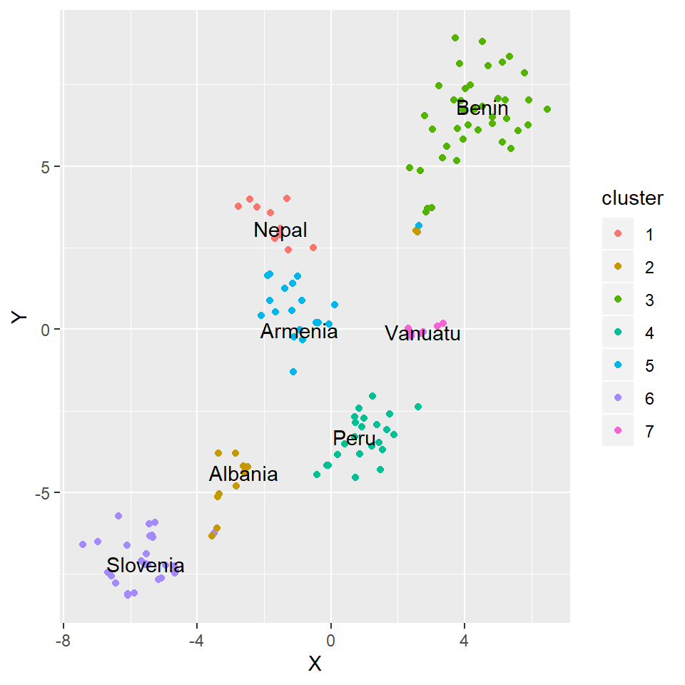

```r
tsne_obj <- Rtsne(gower_dist, is_distance = TRUE)

tsne_data <- tsne_obj$Y %>%
  data.frame() %>%
  setNames(c("X", "Y")) %>%
  mutate(cluster = factor(pam_fit$clustering),
         name = data_clean$Country)

ggplot(aes(x = X, y = Y), data = tsne_data) +
  geom_point(aes(color = cluster)) +
  geom_text(data=subset(tsne_data[pam_fit$medoids, ]), # add names of centroids in
            aes(X,Y,label=name))
```

## cluster the same data set using kmeans

different implementations of k-means are provided throught the algorithm argument to kmeans() method for all country attrubutes

To know more about the differences see https://core.ac.uk/download/pdf/27210461.pdf kmeans() take numeric data,

```r
# z-score transformation to scale the variables. Scaling is needed because we will use euclidean distant
data_scaled <- data %>%
  select(-c(Status,region)) %>%  # remove factor variables
  mutate_at(scale, .vars=vars(-Country))
data_scaled %>% head()
```

```
## # A tibble: 6 x 15
##   Country `Life expectanc~ `Adult Mortalit~ `infant deaths`~ Alcohol[,1]
##   <fct>              <dbl>            <dbl>            <dbl>       <dbl>
## 1 Afghan~           -1.29             1.08            0.378      -0.985
## 2 Albania            0.723           -0.626          -0.275       0.141
## 3 Algeria            0.502           -0.367          -0.0675     -0.862
## 4 Angola            -2.31             1.88            0.407       0.932
## 5 Argent~            0.583           -0.303          -0.196       0.975
## 6 Armenia            0.397           -0.266          -0.265      -0.0893
## # ... with 10 more variables: BMI[,1] <dbl>, `under-five
## #   deaths`[,1] <dbl>, `Total expenditure`[,1] <dbl>,
## #   Diphtheria[,1] <dbl>, GDP[,1] <dbl>, Population[,1] <dbl>, `thinness
## #   1-19 years`[,1] <dbl>, `thinness 5-9 years`[,1] <dbl>, `Income
## #   composition of resources`[,1] <dbl>, Schooling[,1] <dbl>
```

get distance matrix, excluding first column: Country

note: nstart is the parameter that allows the user to try multiple sets of initial centroids. You should use a nstart > 1, for example, nstart=25, this will run kmeans nstart number of times, each time with a different set of initial centroids. kmeans will then select the one with the lowest within cluster variation.

```r
dist_mat <- dist(data_scaled[, -1], method="euclidean")
rownames
```

[output not shown]

```r
avgS <- c() #initiate an empty vector

for(k in 2:10){
  kmeans_cl <- kmeans(data_scaled[,-1], centers=k, iter.max=500, nstart=1)
  s <- silhouette(kmeans_cl$cluster, dist_mat)
  avgS <- c(avgS, mean(s[,3])) # take the mean of sil_width of all observations, and save it in the avgS vector
}

data.frame(nClus=2:10, Silh=avgS)
```

```
##   nClus      Silh
## 1     2 0.2772878
## 2     3 0.1967915
## 3     4 0.1777214
## 4     5 0.2009472
## 5     6 0.2207819
## 6     7 0.2233378
## 7     8 0.2277167
## 8     9 0.1863636
## 9    10 0.1737121
```

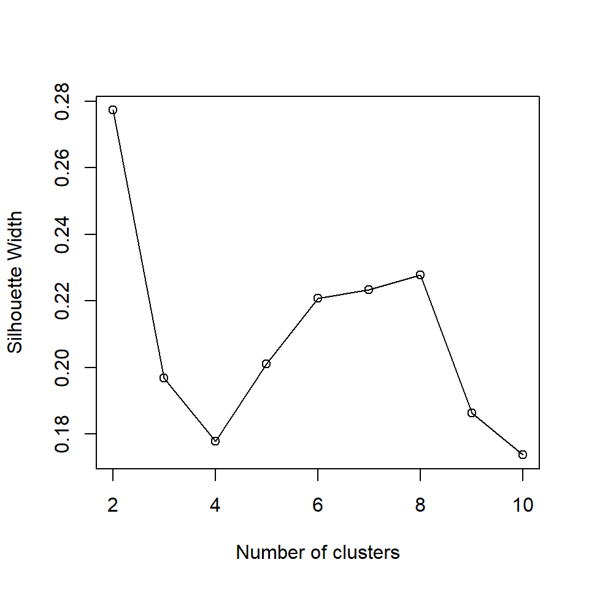

```r
plot(2:10, avgS,
  xlab = "Number of clusters",
  ylab = "Silhouette Width",
  lines(2:10, avgS))
```

```r
kmeans_fit <- kmeans(data_scaled[,-1], 2)
```

get cluster means

```r
aggregate(data_scaled[,-1],by=list(kmeans_fit$cluster),FUN=mean)
```

```
##   Group.1 Life expectancy Adult Mortality infant deaths    Alcohol
## 1       1       0.7163688      -0.5409467    -0.2436040  0.5595847
## 2       2      -0.7923473       0.5983198     0.2694408 -0.6189346
##          BMI under-five deaths Total expenditure Diphtheria        GDP
## 1  0.5952935        -0.2502674         0.2596706  0.3295382  0.3346528
## 2 -0.6584307         0.2768109        -0.2872114 -0.3644892 -0.3701462
##   Population thinness  1-19 years thinness 5-9 years
## 1 -0.1548963           -0.5567285         -0.5685360
## 2  0.1713247            0.6157754          0.6288353
##   Income composition of resources  Schooling
## 1                       0.7569109  0.7218337
## 2                      -0.8371893 -0.7983918
```

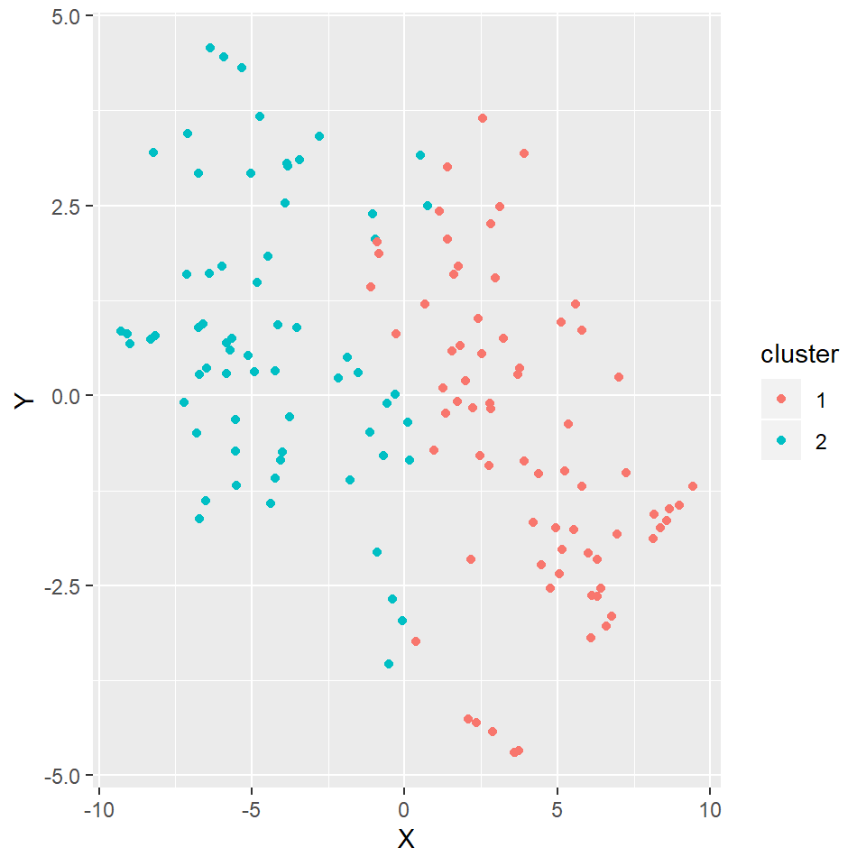

```r
data_scaled <- data.frame(data_scaled, kmeans_fit$cluster)

# Cluster Interpretation:via visualization
tsne_obj <- Rtsne(dist_mat, is_distance = TRUE)
tsne_obj$Y %>%
  data.frame() %>%
  setNames(c("X", "Y")) %>%
  mutate(cluster = factor(kmeans_fit$cluster),
         name = data_scaled$name) %>%
  ggplot(aes(x = X, y = Y)) +
  geom_point(aes(color = cluster))
```

Now try 7 clusters

```r
kmeans_fit <- kmeans(data_scaled[,-1], 7)
```

get cluster means

```r
aggregate(data_scaled[,-1],by=list(kmeans_fit$cluster),FUN=mean)
```

```
##   Group.1 Life.expectancy Adult.Mortality infant.deaths     Alcohol
## 1       1       0.9482413      -0.6200627   -0.24365821  1.16934824
## 2       2      -0.9326311       0.7409583    0.01160209 -0.66607175
## 3       3      -1.0138693       0.8074308    5.86873787 -0.08298487
## 4       4       0.1966800      -0.2793621   -0.19248651 -0.34227138
## 5       5      -1.2464939       0.9770181   -0.09063395 -0.26550155
## 6       6       1.3409697      -0.8379515   -0.26666132  1.29586548
## 7       7       0.7029704      -0.5388962   -0.09633038  0.50909897
##          BMI under.five.deaths Total.expenditure Diphtheria        GDP
## 1  1.0338084       -0.24992379       0.703838038  0.4986398  0.1183168
## 2 -0.7951765        0.02760934      -0.058914534 -0.1260013 -0.3920852
## 3 -0.8907109        5.92656094      -1.064277019 -1.0662068 -0.3505238
## 4  0.5991341       -0.20504083      -0.388950313  0.2617384 -0.2369089
## 5 -0.5222129       -0.06523912      -0.657859980 -3.8994944 -0.2910814
## 6  0.7067238       -0.27150312       1.096798589  0.4934636  3.5746307
```

[output cut: 17 more lines]

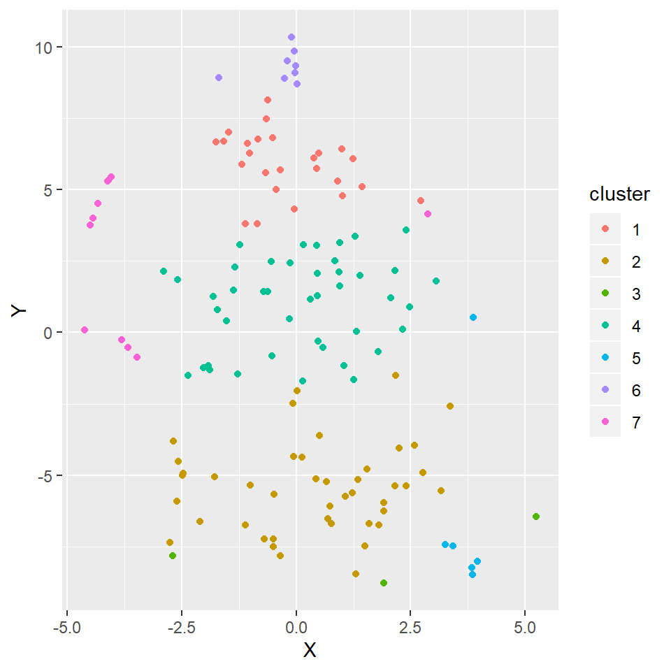

```r
data_scaled <- data.frame(data_scaled, kmeans_fit$cluster)

# Cluster Interpretation:via visualization
tsne_obj <- Rtsne(dist_mat, is_distance = TRUE)
tsne_obj$Y %>%
  data.frame() %>%
  setNames(c("X", "Y")) %>%
  mutate(cluster = factor(kmeans_fit$cluster),
         name = data_scaled$name) %>%
  ggplot(aes(x = X, y = Y)) +
  geom_point(aes(color = cluster))
```

```r
kmeans_fit <- kmeans(data_scaled[,-1], 9)
```

get cluster means

```r
aggregate(data_scaled[,-1],by=list(kmeans_fit$cluster),FUN=mean)
```

```
##   Group.1 Life.expectancy Adult.Mortality infant.deaths       Alcohol
## 1       1    -0.198391006     -0.01275510  -0.003788278 -0.8931166495
## 2       2     1.132334588     -0.77840325  -0.266042961  1.0654974273
## 3       3    -1.126988739      0.94047068   0.015676016 -0.6059716269
## 4       4     0.948241323     -0.62006266  -0.243658215  1.1693482363
## 5       5    -0.005344926      0.05874137  -0.045287316 -0.5795230908
## 6       6    -0.393537169      0.32641952   9.618492020 -0.2504893578
## 7       7    -1.324035429      1.04793643   3.993860792  0.0007673784
## 8       8     0.296194667     -0.43764839  -0.216285339 -0.2175415405
## 9       9    -1.246493908      0.97701811  -0.090633947 -0.2655015527
##          BMI under.five.deaths Total.expenditure Diphtheria        GDP
## 1 -0.9818186       -0.01810478       -0.54745110  0.0477354 -0.3901147
## 2 -0.4042610       -0.27011983        0.64735774  0.4151396  1.7179020
## 3 -0.7457712        0.03971014        0.07040397 -0.1719904 -0.3926068
## 4  1.0338084       -0.24992379        0.70383804  0.4986398  0.1183168
```

[output cut: 35 more lines]

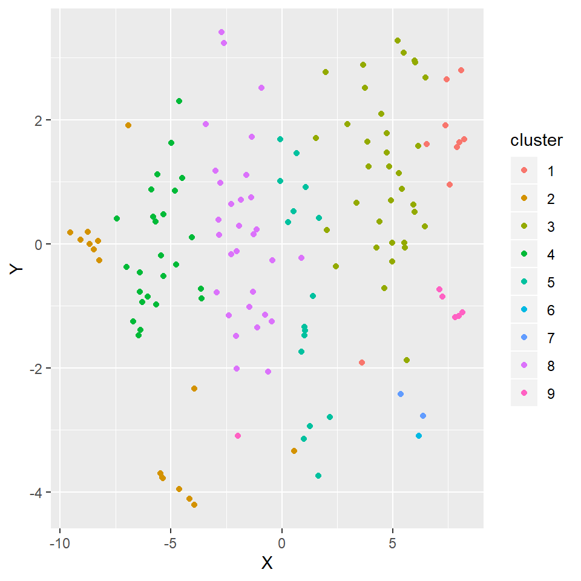

```r
data_scaled <- data.frame(data_scaled, kmeans_fit$cluster)

# Cluster Interpretation:via visualization
tsne_obj <- Rtsne(dist_mat, is_distance = TRUE)
tsne_obj$Y %>%
  data.frame() %>%
  setNames(c("X", "Y")) %>%
  mutate(cluster = factor(kmeans_fit$cluster),
         name = data_scaled$name) %>%
  ggplot(aes(x = X, y = Y)) +
  geom_point(aes(color = cluster))
```

After trying kmeans multiple times, the optimum clusters seem to be two, all other clusters are outliers, which might prove interesting with future research.

## 2.Run a hierarchical method on your dataset, try a couple of different cuts. Are these results more meaningful than those from the participation method?

> method argument takes the agglomeration method to be used. This should be (an unambiguous abbreviation of) one of:

> “ward.D”, “ward.D2”, “single”, “complete”, “average” (= UPGMA), “mcquitty” (= WPGMA), “median” (= WPGMC) or “centroid” (= UPGMC).

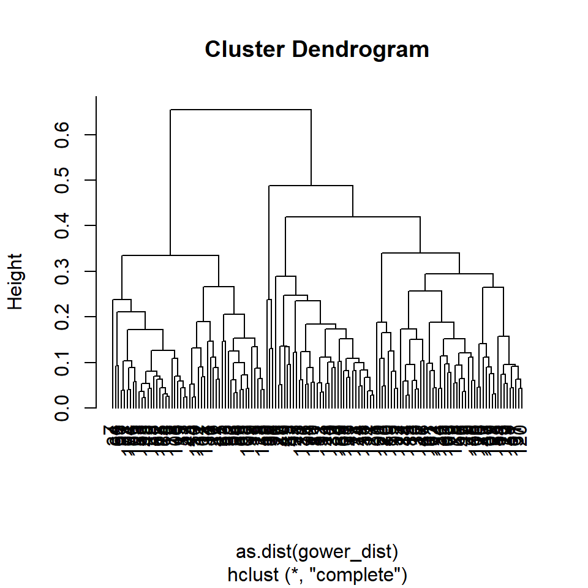

```r
h <- hclust(d = as.dist(gower_dist), method="complete")
# plot the dendrogram #hang decides where to start labels on axis. -0.1 is negative, so the x-axis labels will hang down from 0
plot(h, hang=-0.1)
```

a nicer dengrogram (kind of) since the last one doesn’t have labels

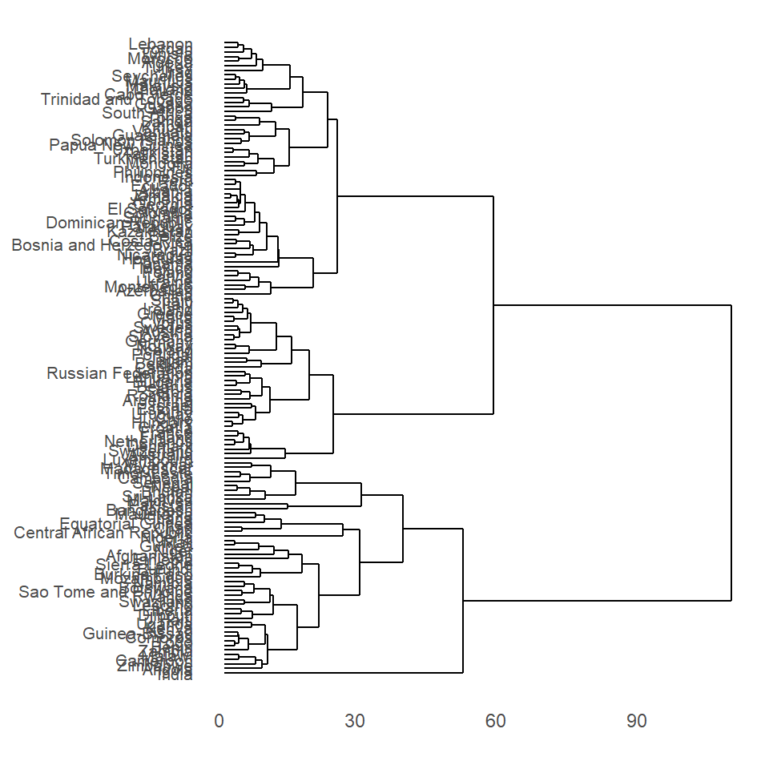

```r
data_dendro <- data %>% select(-c(region, Status,Country)) %>% scale()
rownames(data_dendro) <- data$Country
data_dendro <- dist(data_dendro, method="manhattan")
data_dendro <- as.dendrogram(hclust(data_dendro, method="ward.D2"))
dendro.plot <- ggdendrogram(data = data_dendro, rotate = TRUE) +
  theme(axis.text.y = element_text(size = 8))
print(dendro.plot) #better plot
```

If we want to cluster at a height of about 0.3 is shows 6 clusters at the 3rd level. They seem to be evenly spread except cluster 6.

```r
clus <- cutree(h, h=.3)
table(clus)
```

```
## clus
##  1  2  3  4  5  6
##  8 26 42 34 26  3
```

At just 3 clusters we find a disproportionate amount of variables per cluster.

```r
clus3 <- cutree(h, 3)
table(clus3)
```

```
## clus3
##  1  2  3
## 84 52  3
```

the height of .4 is similar to .3, where two of the clusters were now combined.

```r
clus <- cutree(h, h=.4)
table(clus)
```

```
## clus
##  1  2  3  4
## 50 52 34  3
```

Four clusters are exactly the same as a .4 height.

```r
clus <- cutree(h, 4)
table(clus)
```

```
## clus
##  1  2  3  4
## 50 52 34  3
```

```r
clus <- cutree(h, h=.2)
#plot(clus)
table(clus)
```

```
## clus
##  1  2  3  4  5  6  7  8  9 10 11 12 13 14 15 16 17
##  8 11  9 26 13 17  1 23  2  9  2  5  2  2  7  1  1
```

```r
clus <- cutree(h, h=.5)
table(clus)
```

```
## clus
##  1  2
## 87 52
```

As expected, the lower height you go (.2), the more clusters with a disperesed amount of variables in each. Whereas if you go to a higher height (.5) the less clusters you get with very different variables in each.

```r
clus <- cutree(h, 7)
table(clus)
```

```
## clus
##  1  2  3  4  5  6  7
##  8 26 26 34 26  3 16
```

```r
table(result1$pam_fit.cluster, clus)
```

```
##    clus
##      1  2  3  4  5  6  7
##   1  8  0  0  0  0  3  0
##   2  0 10  2  0  0  0  0
##   3  0  0  6 34  0  0  0
##   4  0 14  0  0  0  0  9
##   5  0  1 18  0  0  0  0
##   6  0  1  0  0 26  0  0
##   7  0  0  0  0  0  0  7
```

## use DIANA in the cluster package for divisive hierarchical clustering

because we provided a dissimilarity matrix, we don’t need to supply other arguments to this function. dissimilarity matrix incoporated the distance measures and data normalization

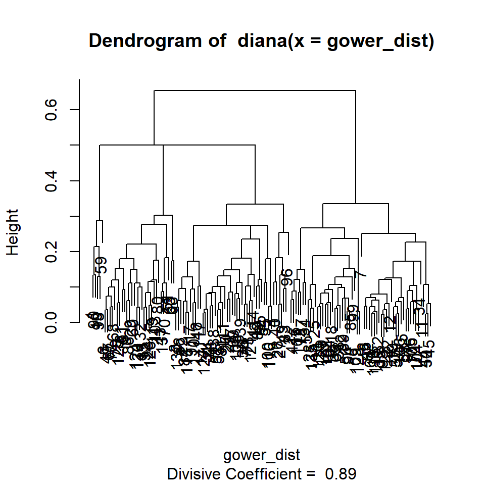

```r
d <- diana(gower_dist)
d7 <- cutree(d, 7)

# visualize Diana
plot(d, which = 2, nmax.lab = 100)
```

```r
table(result1$pam_fit.cluster, d7)
```

```
##    d7
##      1  2  3  4  5  6  7
##   1  5  0  0  0  6  0  0
##   2  0  7  2  0  0  3  0
##   3  0  0 33  7  0  0  0
##   4  0 20  2  0  1  0  0
##   5  0  0  1  0 17  0  1
##   6  0  0  0  0  0 26  1
##   7  0  2  2  0  3  0  0
```

```r
table(clus, d7) # versus the hclust from above
```

```
##     d7
## clus  1  2  3  4  5  6  7
##    1  2  0  0  0  6  0  0
##    2  0 21  0  0  0  4  1
##    3  0  0  9  0 17  0  0
##    4  0  0 27  7  0  0  0
##    5  0  0  0  0  0 25  1
##    6  3  0  0  0  0  0  0
##    7  0  8  4  0  4  0  0
```